# Linear Methods for Classification:

We have seen that boundaries of classification regions can be rough or smooth depending on the prediction function. For an important class of procedures, these direction boundaries are linear this is what we will mean by linear methods for classification. As always I will follow Elements of Statistical Learning and here I will provide the codes for the most used methods on this topic but if you want to learn in details you should study the book in details. It's a fun read.

### Linear Discriminant Analysis:

[figure not shown]

```python
#Importing Libraries:
import numpy as np
import pandas as pd
```

```python
#Importing Dataset:
url = "https://archive.ics.uci.edu/ml/machine-learning-databases/iris/iris.data"
names = ['sepal-length', 'sepal-width', 'petal-length', 'petal-width', 'Class']
dataset = pd.read_csv(url, names=names)
```

```python
#Data Preprocessing:
X = dataset.iloc[:, 0:4].values
y = dataset.iloc[:, 4].values
from sklearn.model_selection import train_test_split

X_train, X_test, y_train, y_test = train_test_split(X, y, test_size=0.2, random_state=0)
```

```python
#Feature Scaling
from sklearn.preprocessing import StandardScaler

sc = StandardScaler()
X_train = sc.fit_transform(X_train)
X_test = sc.transform(X_test)
```

```python
#Performing LDA
from sklearn.discriminant_analysis import LinearDiscriminantAnalysis as LDA

lda = LDA(n_components=1)
X_train = lda.fit_transform(X_train, y_train)
X_test = lda.transform(X_test)
```

```python
#Training
from sklearn.ensemble import RandomForestClassifier

classifier = RandomForestClassifier(max_depth=2, random_state=0)

classifier.fit(X_train, y_train)
y_pred = classifier.predict(X_test)
```

```python
#Test
from sklearn.metrics import confusion_matrix
from sklearn.metrics import accuracy_score

cm = confusion_matrix(y_test, y_pred)
print(cm)
print('Accuracy' + str(accuracy_score(y_test, y_pred)))
```

```
[[11  0  0]
 [ 0 13  0]
 [ 0  0  6]]
Accuracy1.0
```

While it might look like LDA is a great option irrespective of the situation but that is not always the case. It is advisable to use LDA when the data is uniformly distributed.

### Logistic Regression:

The logistic Regression model arises from the desire to model the posterior probabilities of the K classes via linear functions in x, while at the same time ensuring that they sum up to 1 and remain in [0,1] , The model has the form:

[figure not shown]

The logistic regression models are used mostly as a data analysis and inference tools, in which the goal is to understand the role of the input variables in explaining outcome.

#### Example: South African Heart Disease

Here I will present an analysis of binary data to illustrate the traditional statistical use of the logistic regression model. The data are a subset of Coronary Risk Factor Study baseline survey,carried out in three rural areas of the western Cape, South Africa. The aim of this study was to establish the intensity of ischemic hear disease risk factors in that high incidence region. The data represent white males between 15 and 64, and the response variable is the presence or absence of myocardial infarction (MI) at the time of the survey ( the overall prevalence of MI was 5.1% in this region). There are 160 cases in our data set and a sample of 302 controls.

```python
#Importing

import pandas as pd
import numpy as np
import seaborn as sns
from matplotlib import transforms , pyplot as plt
%matplotlib inline
```

```python
#Loading and Preparing Data

df = pd.read_csv("South African Heart Disease.txt")

#encode famhist with dummy 0-1 variable, giving present = 1
df['famhist'] = pd.get_dummies(df['famhist'])['Present']
target = 'chd'
features = ['sbp','tobacco','ldl','famhist','obesity','alcohol','age']
df[features + [target]].head() #Data Snippet
```

|  | sbp | tobacco | ldl | famhist | obesity | alcohol | age | chd |
| --- | --- | --- | --- | --- | --- | --- | --- | --- |
| 0 | 160 | 12.00 | 5.73 | 1 | 25.30 | 97.20 | 52 | 1 |
| 1 | 144 | 0.01 | 4.41 | 0 | 28.87 | 2.06 | 63 | 1 |
| 2 | 118 | 0.08 | 3.48 | 1 | 29.14 | 3.81 | 46 | 0 |
| 3 | 170 | 7.50 | 6.41 | 1 | 31.99 | 24.26 | 58 | 1 |
| 4 | 134 | 13.60 | 3.50 | 1 | 25.99 | 57.34 | 49 | 1 |

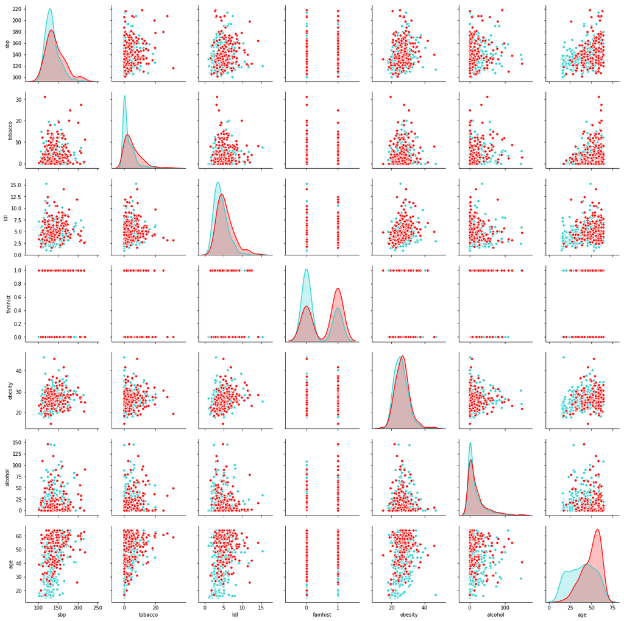

```python
#A scatterplot matrix, each plot shows pair of risk factors,and
#the case and controls are color coded (red is a case)
sns.pairplot(
    df, vars=features, kind="scatter", hue=target,
    palette=['#29CFD0', '#FF0000'], plot_kws=dict(s=30, linewidth=1)
)._legend.remove()
```

```python
# convert data to X, y np.arrays
X, y = df[features].values, df[target].values
```

```python
#Logistic Regression pre-requisite
import statsmodels.api as sm
from scipy import stats
```

```python
#Basic Logistic Regression
lr = sm.Logit(y,sm.add_constant(X)).fit(disp = False)
result = zip(['(Intercept)']+features,lr.params , lr.bse , lr.tvalues)
print('               Coefficient   Std. Error   Z Score')
print('-------------------------------------------------')
for term, coefficient, std_err, z_score in result:
    print(f'{term:>12}{coefficient:>14.3f}{std_err:>13.3f}{z_score:>10.3f}')
```

```
               Coefficient   Std. Error   Z Score
-------------------------------------------------
 (Intercept)        -4.130        0.964    -4.283
         sbp         0.006        0.006     1.023
     tobacco         0.080        0.026     3.034
         ldl         0.185        0.057     3.218
     famhist         0.939        0.225     4.177
     obesity        -0.035        0.029    -1.187
     alcohol         0.001        0.004     0.136
         age         0.043        0.010     4.181
```

#### Features Selection

Now we try to find subset of the original features which explains most of the variability. A better but more time consuming strategy is to refit each of the models with one variable removed, and then perform an analysis of deviance to decide which variable to exclude. The residual deviance of a fitted model is minus twice its log-likelihood, and the deviance between two models is the difference of their individual residual deviances (in analogy to sums-of squares).

```python
from sklearn.metrics import log_loss
from sklearn.linear_model import LogisticRegression
```

```python
# calculates total deviance of a model on a data set
def deviance(X, y, model):
    return 2*log_loss(y, model.predict_proba(X), normalize=False)


# calculates total deviance of a model trained on features subset
def subset_deviance(model, selected_ids):
    X_selected = X[:, sorted(list(selected_ids))]
    model.fit(X_selected, y)
    return deviance(X_selected, y, model)


lr = LogisticRegression(solver='lbfgs', max_iter=100000, C=10e10)
# start with all features selected, store features indices
selected_ids = set(range(len(features)))
current_deviance = subset_deviance(lr, selected_ids)
while True:
    # what would be the total deviance if we remove a feature?
    deviances = [
        (subset_deviance(lr, selected_ids - set([idx])), idx)
        for idx in selected_ids]
    # find a feature to remove to minimize resulting total deviance
    min_deviance, feature_to_remove_idx = min(deviances)
    # the difference between the deviances for the two models follows
    # an approximate chi-squared distribution. Use it for stopping criteria.
    deviance_diff = min_deviance - current_deviance
    p_value = 1 - stats.chi2.cdf(deviance_diff, df=1)
    if p_value < 0.05:
        break
    selected_ids -= set([feature_to_remove_idx])
    current_deviance = min_deviance
    print(f'REMOVE: {features[feature_to_remove_idx]}')

# selected feature names
selected_ids = sorted(list(selected_ids))
features_selected = [features[i] for i in selected_ids]
```

```
REMOVE: alcohol
REMOVE: sbp
REMOVE: obesity
```

```python
#Now let's refit again
lr = sm.Logit(y, sm.add_constant(X[:, selected_ids])).fit(disp=False)
result = zip(['(Intercept)']+features_selected, lr.params, lr.bse, lr.tvalues)
print('               Coefficient   Std. Error   Z Score')
print('-------------------------------------------------')
for term, coefficient, std_err, z_score in result:
    print(f'{term:>12}{coefficient:>14.3f}{std_err:>13.3f}{z_score:>10.2f}')
```

```
               Coefficient   Std. Error   Z Score
-------------------------------------------------
 (Intercept)        -4.204        0.498     -8.44
     tobacco         0.081        0.026      3.16
         ldl         0.168        0.054      3.09
     famhist         0.924        0.223      4.14
         age         0.044        0.010      4.52
```

#### L1 Regularized Logistic Regression

```python
from sklearn.preprocessing import StandardScaler
```

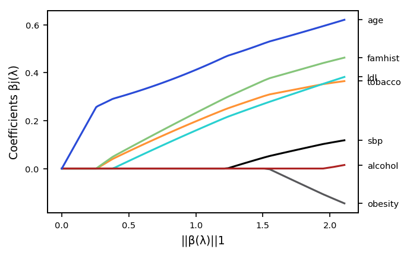

```python
lr = sm.Logit(y, sm.add_constant(StandardScaler().fit_transform(X)))
# for different alpha values fit a model and save coefficients
alpha = np.linspace(0, 82, 100)
coefs = np.vstack([lr.fit_regularized(disp=False, alpha=a).params[1:]
                   for a in alpha])
# calculate sum of coefficients for different alpha values
coefs_l1_norm = np.sum(np.abs(coefs), axis=1)

fig, ax1 = plt.subplots(figsize=(4.5, 3), dpi=150)
colors = ['#000101', '#FF9234', '#29D0D0', '#85C57A', '#57575A', '#AD2323',
          '#2A4BD7']
for i in range(7):
    ax1.plot(coefs_l1_norm, coefs[:, i], color=colors[i])
ax2 = ax1.twinx()
ax2.set_ylim(ax1.get_ylim())
plt.setp(ax2, yticks=coefs[0], yticklabels=features)
for i in ax1.get_yticklabels() + ax1.get_xticklabels() + ax2.get_yticklabels():
    i.set_fontsize(7)
ax1.set_xlabel('||β(λ)||1', fontsize=9)
_ = ax1.set_ylabel('Coefficients βj(λ)', fontsize=9)
```

As we can see from this plot as well , alcohol , sbp and obesity have the least significant effect on the outcome.

### Logistic Regression or LDA?

It is generally felt that logistic regression is a safer, more robust bet than the LDA model. relying on fewer assumptions. It is my experience that the models give very similar results, even when LDA is used inappropriately, such as with qualitative predictors.